[GitHub Python Bar Review](https://github.com/ckorikov/python-bar-review)

# Конкурентное программирование

## 1. Конкурентное != параллельное

Мы говорим о многозадачности, то есть о выполнении нескольких задач в один и тот же период времени. С многозадачностью связывают конкурентное, параллельное и асинхронное выполнение задач.

**Конкурентные задачи** (англ. concurrent tasks) — задачи, выполнение которых пересекается во времени. Задачи могут выполняться параллельно, а могут порционно (виртуальный параллелизм).

**Параллельные задачи** (англ. parallel tasks) — задачи, которые буквально выполняются одновременно.

Из определений видно, что конкурентность и параллелизм различаются. Это две независимые характеристики, которые образуют 4 вида многозадачности.

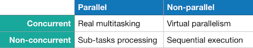

На рисунке ниже показано различие между последовательным, конкурентным и параллельным выполнением задач. Круги — этапы вычислений, а стрелки показывают последовательность вычислений.

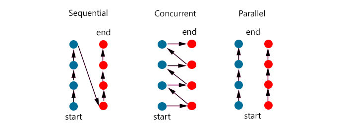

**Асинхронные задачи** (англ. asynchronous tasks) — задачи, которые запущены без ожидания результата. Таким образом, асинхронная задача не блокирует запускающую систему. Обычно асинхронные задачи по окончанию вызывают функцию обратного вызова (англ. callback function).

В противоположность асинхронным задачам ставят синхронные. На рисунке ниже показано время синхронного и асинхронного выполнения задач.

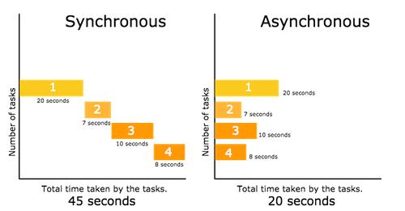

Организовать выполение задач конкурентно можно двумя сопособами:

- решение с общей памятью (англ. shared memory),
- решение с передачей сообщений (англ. message passing).

Оба подхода могут быть использованы на машинах с разной архитектурой. Но если задачи выполняются на машине с физически разделеённой памятью, то проще огранизовать конкурентую работу на передаче сообщений.

## 2. Подход с общей памятью

В этом подходе конкурентные задачи взаимодействуют через общии участки памяти. Такая система может быть построена на разных сущностях:

- процессы,
- потоки,
- кооперативные потоки: «зелёные потоки», протопотоки, файберы и корутины.

### 2.1. Синхронизация

#### Критическая секция и «гонки»

При этом доступ к общему ресурсу могут возникнуть «гонки» (англ. race condition) — проблема, при которой работа системы или приложения зависит от того, в каком порядке выполняются конкурентные части программы. Эти части, которые могут приводить к «гонкам», называют критическими секциями (англ. critical section). Перед входом в критическую секцию конкурентные задачи надо синхронизовать.

[figure not shown]

Различают следующие классические примитивные способы синхронизации:

- Семафор
  - Семафор со счётчиком (англ. counting semaphore)
  - Бинарный семафор (англ. binary semaphore), он жe lock
    - RWLock (=Readers-Writes lock)
  - Событие (англ. event)
    - Условная переменная (англ. conditional variable)
- Мьютекс (англ. mutex = mutual exclusion)
  - Рекурсивный мьютекс (англ. recursive mutex)
  - Shared-мьютекс (shared mutex)
  - Спин-блокировка (англ. spin lock)
  - Фьютекс (англ. futex = fast userspace mutex)
- Монитор (англ. monitor)
- Барьер aka Рандеву

**NB!** Избежать синхронизации можно разработкой программы без блокировок.

### 2.2. Processes

Процесс (анг. process) — загруженная в память программа. Процессы относятся к основному механизму многозадачности операционных систем. Процессы запускаются конкурентно и переключение между процессами (англ. scheduling) контролируется операционной системой. Она делает это по таймеру. Такую схему преключения называют вытесняющей многозадачностью.

#### Время жизни процессов в Unix. Низкоуровневая работа с процессами

Посмотреть список процессов в unix-подобной операционной системе можно следующей командой.

```python
!ps xo 'pid ppid stat comm'
```

```
  PID  PPID STAT COMMAND
    1     0 Ss   sh
    6     1 Sl   jupyter-lab
  205     6 Rsl  python
  216   205 Ss+  sh
  217   216 R+   ps
```

Здесь `PID` — идентификатор процесса, `PPID` — идентификатор родительского процесса. В unix-системах состояние процессов представляет собой дерево, где в корне находится процесс под номером 1.

Мы можем создать новый процесс только через клонирование другого процесса. Это делается системным вызовом `fork`. Этим вызовом создётся виртуальное адресное пространство нового процесса и ему присваевается `PID`. Однако, явного копирования памяти родительского процесса в дочерний не происходит. Только если в родительском, либо в дочернем процессе выполняется запись в определённое адресное простраство, то оно копируется. Этот механизм называется copy-on-write.

Вызвать `fork` можно с помощью модуля `os`.

```python
import os

child = os.fork() # возвращает pid дочернего процесса
print(f'pid: {child}')
```

```
pid: 0
pid: 218
```

Видно, что `print` выполнился 2 раза. Один раз код был выполнен в child-процессе, а другой — в parent. В child-процессе `os.fork` возвращает 0, а в parent-процессе — `PID` дочернего процесса. Проверкой на 0 можно понять где мы запущены.

Дочерний процесс должен появиться в списке процессов системы с соответвующим `PID`.

```python
!ps xo 'pid ppid stat comm'
```

```
  PID  PPID STAT COMMAND
    1     0 Ss   sh
    6     1 Sl   jupyter-lab
  205     6 Ssl  python
  218   205 R    python
  221   205 Ss+  sh
  222   221 R+   ps
```

Общение между приложениями и ядром операционной системы выполняется через два механизма:

- системные вызовы,
- сигналы.

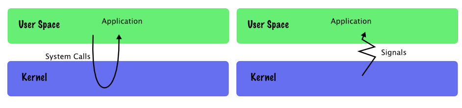

Посмотрим несколько первых сигналов, поддерживаемых в системе

```python
!kill -l | head
```

```
0
HUP
INT
QUIT
ILL
TRAP
ABRT
BUS
FPE
KILL
```

```python
import signal

os.kill(child, signal.SIGKILL)
```

```python
!ps xo 'pid ppid stat comm'
```

```
  PID  PPID STAT COMMAND
    1     0 Ss   sh
    6     1 Sl   jupyter-lab
  205     6 Ssl  python
  218   205 Z    python <defunct>
  226   205 Ss+  sh
  227   226 R+   ps
```

`Z` — зомби-процесс, он как бы мёртв, но ядро хранит код возврата и `PID`.

```python
# Читаем код возврата
os.waitpid(0, 0)
```

```
(218, 9)
```

```python
!ps xo 'pid ppid stat comm'
```

```
  PID  PPID STAT COMMAND
    1     0 Ss   sh
    6     1 Sl   jupyter-lab
  205     6 Rsl  python
  228   205 Ss+  sh
  229   228 R+   ps
```

#### Работа с процессами в Python

```python
from multiprocessing import Process

def fun_in_child():
    print('Hello from child!')

p = Process(target=fun_in_child)
p.start()
p.join()
```

```
Hello from child!
```

```python
!ps xo 'pid ppid stat comm'
```

```
  PID  PPID STAT COMMAND
    1     0 Ss   sh
    6     1 Sl   jupyter-lab
  205     6 Ssl  python
  233   205 Ss+  sh
  234   233 R+   ps
```

#### Межпроцессное взаимодействие

Для параллельной работы процессы используют механизмы межпроцессного взаимодействия (англ. inter-process communication, IPC):

- Сокеты: Unix-сокеты, Беркли-сокеты, Windows-сокеты *linux, windows, mac*
- Анонимный канал (англ. pipe) *linux, windows*
- Именованный канал (англ. fifo) *linux*
- Сегменты общей памяти (shared memory segments) *linux*
- Очереди сообщений (англ. message queues) *mac, linux*
- Сигналы (англ. signals) *linux*
- Отображение файлов (англ. file mapping) *linux, windows, mac*
- Удаленный вызов процедур (англ. Remote Procedure Call) *windows, mac*
- Шина dbus *linux*
- Система FUSE *linux*
- Mailslots *windows*
- Буфер обмена (англ. clipboard) *windows*
- Система Dynamic Data Exchange *windows*

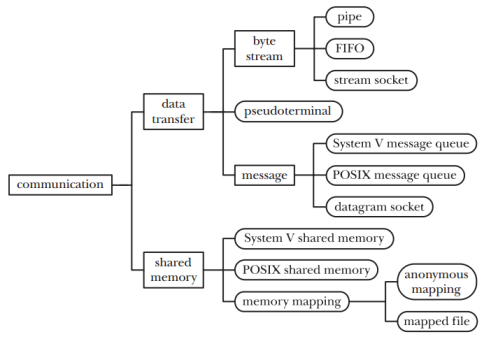

```python
from multiprocessing import Process, Queue

def f(q):
    q.put([42, None, 'hello'])

if __name__ == '__main__':
    q = Queue()
    p = Process(target=f, args=(q,))
    p.start()
    print(q.get())    # prints "[42, None, 'hello']"
    p.join()
```

```
[42, None, 'hello']
```

### 2.3. Threads

Поток (анг. thread) — подзадача процесса. Потоки ещё называют «лёгкими процессами» (англ. light weight process). Переключение между потоками также контролируются операционной системой. Здесь также присутсвует вытесняющая многозадачность — переключение по таймеру. Все потоки одного процесса обладают общей виртуальной памятью.

Посмотреть список потоков и процессов в unix-подобной операционной системе можно следующей командой. Мы добавили `-T` к предыдущей.

```python
!ps -Tef
```

```
UID        PID  SPID  PPID  C STIME TTY          TIME CMD
root         1     1     0  0 21:19 ?        00:00:00 /bin/sh -c pipenv run jupy
root         6     6     1  1 21:19 ?        00:00:29 /usr/local/bin/python /usr
root         6    30     1  0 21:20 ?        00:00:00 /usr/local/bin/python /usr
root         6    40     1  0 21:20 ?        00:00:00 /usr/local/bin/python /usr
root         6    41     1  0 21:20 ?        00:00:00 /usr/local/bin/python /usr
root         6    53     1  0 21:20 ?        00:00:00 /usr/local/bin/python /usr
root         6    54     1  0 21:20 ?        00:00:00 /usr/local/bin/python /usr
root         6   117     1  0 21:41 ?        00:00:00 /usr/local/bin/python /usr
root         6   118     1  0 21:41 ?        00:00:00 /usr/local/bin/python /usr
root         6   129     1  0 21:45 ?        00:00:00 /usr/local/bin/python /usr
root         6   142     1  0 21:49 ?        00:00:00 /usr/local/bin/python /usr
root         6   143     1  0 21:49 ?        00:00:00 /usr/local/bin/python /usr
root         6   155     1  0 21:49 ?        00:00:00 /usr/local/bin/python /usr
root         6   156     1  0 21:49 ?        00:00:00 /usr/local/bin/python /usr
root       205   205     6  4 21:50 ?        00:00:01 /usr/local/bin/python -m i
root       205   208     6  0 21:50 ?        00:00:00 /usr/local/bin/python -m i
root       205   209     6  0 21:50 ?        00:00:00 /usr/local/bin/python -m i
root       205   210     6  0 21:50 ?        00:00:00 /usr/local/bin/python -m i
root       205   211     6  0 21:50 ?        00:00:00 /usr/local/bin/python -m i
root       205   212     6  0 21:50 ?        00:00:00 /usr/local/bin/python -m i
root       205   213     6  0 21:50 ?        00:00:00 /usr/local/bin/python -m i
root       205   214     6  0 21:50 ?        00:00:00 /usr/local/bin/python -m i
root       205   215     6  0 21:50 ?        00:00:00 /usr/local/bin/python -m i
root       237   237   205 99 21:51 pts/0    00:00:01 /bin/sh -c ps -Tef
root       238   238   237  0 21:51 pts/0    00:00:00 ps -Tef
```

Здесь `SPID` — идентификатор потока.

```python
from threading import Thread
```

```python
def subproc(n: int):
    [print(i) for i in range(n)]

thread1 = Thread(target=subproc, args=(5,))
thread2 = Thread(target=subproc, args=(5,))

thread1.start()
thread2.start()
thread1.join()
thread2.join()
```

```
0
1
2
3
4
0
1
2
3
4
```

```python
class MyThread(Thread):
    def __init__(self, n:int):
        super().__init__(name=f"Up to {n}")
        self.n = n
    def run(self):
        [print(i) for i in range(self.n)]

thread1 = MyThread(5)
thread2 = MyThread(5)

thread1.start()
thread2.start()
thread1.join()
thread2.join()
```

```
0
1
2
3
4
0
1
2
3
4
```

#### Демонизация потоков

Процесс будет работать до тех пор, пока все потоки не будут завершены. Если надо по явному завершению процесса прекратить работу всех дочерних потоков, то их надо сделать демонами.

```python
def subproc(n: int):
    [print(i) for i in range(n)]

thread1 = Thread(target=subproc, args=(5,), daemon=True)
thread2 = Thread(target=subproc, args=(5,), daemon=True)

thread1.start()
thread2.start()
thread1.join()
thread2.join()
```

```
0
1
2
3
4
0
1
2
3
4
```

#### GIL (Global Interpreter Lock)

GIL — глобальный lock интерпретатора. Это особенность реализации Python из-за которой нельзя одновременно использовать несколько процессоров для потоков. Все параллельные вычисления в Python реализуются с помощью модулей.

#### Мьютекс

```python
from threading import Lock
```

```python
mutex = Lock()

mutex.acquire()
print(mutex)
# Работа с общими ресурсами
mutex.release()
print(mutex)
```

```
<locked _thread.lock object at 0x7f47542e9840>
<unlocked _thread.lock object at 0x7f47542e9840>
```

```python
x = 0
def fun_inc(n:int):
    global x
    for _ in range(n):
        x += 1

def fun_dec(n:int):
    global x
    for _ in range(n):
        x -= 1

thread1 = Thread(target=fun_inc, args=(5000,))
thread2 = Thread(target=fun_dec, args=(5000,))

thread1.start()
thread2.start()
thread1.join()
thread2.join()

print(x)
```

```
0
```

```python
try:
    mutex.acquire()
    # Работа с общими ресурсами

except:
    # Обрабатываем исключения
    pass

finally:
    mutex.release()
```

#### Рекурсивный мьютекс

```python
from threading import RLock
```

#### Семафор

```python
from threading import Semaphore
```

```python
s = Semaphore(10)

s.acquire()
print(s)
# Работа с общими ресурсами
s.release()
print(s)
```

```
<threading.Semaphore object at 0x7f47542ecb20>
<threading.Semaphore object at 0x7f47542ecb20>
```

#### События

```python
from threading import Event
```

```python
e = Event()

#e.wait() # Ждём, когда кто-нибудь захватит флаг
print(e)
e.set() # Ставим флаг
print(e)
# Работа с общими ресурсами
e.clear() # Снимаем флаг и ждём нового
print(e)
```

```
<threading.Event object at 0x7f47544bd7f0>
<threading.Event object at 0x7f47544bd7f0>
<threading.Event object at 0x7f47544bd7f0>
```

### 2.4. Кооперативные потоки: green threads, protothreads, fibers и coroutines

Эти разновидности потоков объединяет то, что операционная система о таких потоках ничего не знает. Они эмулируются приложением. Вместо вытесняющей многозадачности они управляются кооперативной многозадачностью — поток сам явно объявляет, когда он готов отдать процессорное время другому такому же потоку. Из-за этого такие потоки легче: быстрее создаются и между ними выполняется быстрое переключение.

## 3. Подход с передачей сообщений

Модель передачи сообщений. Существет стандартный интерфейс передачи сообщений (англ. Message Passing Interface, MPI).

- Асинхронная передача сообщений. Actor model
- Синхронная передача сообщений. Communicating sequential processes

## 4. Имеет ли смысл распараллеливать задачу?

**Закон Амдала** (англ. Amdahl’s Law) Закон Амдала показывает во сколько раз меньше времени потребуется параллельной программе для решения задачи по сравнению с последовательной. $$ \text{Speed-up}=\frac{1}{S+P/n} $$

## 5. Аппаратный взгляд на паралелизм

### Классификация Флина

[Классификация Флина](https://en.wikipedia.org/wiki/Flynn%27s_taxonomy)

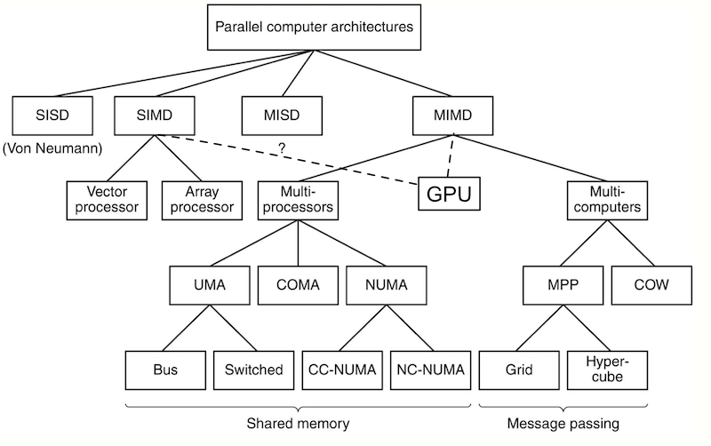

## 6. Почитать

- [(Stackoverflow) Processes, threads, green threads, protothreads, fibers, coroutines: what's the difference?](https://stackoverflow.com/questions/3324643/processes-threads-green-threads-protothreads-fibers-coroutines-whats-the)
- [Такие удивительные семафоры](https://habr.com/en/post/261273/)
- [Как устроен GIL в Python](https://habr.com/en/post/84629/)
- [Parallel Computing vs. Distributed Computing: A Great Confusion?](https://link.springer.com/chapter/10.1007%2F978-3-319-27308-2_4)

```python
%load_ext watermark
%watermark -d -u -v -iv
```

```
last updated: 2019-10-21

CPython 3.8.0
IPython 7.8.0
```